# Plotting solutions

# 3 - Adding a variable

1. To illustrate the development of the medians in the same plot, add `geom_point()` and either `geom_line()` or `geom_smooth()` for `avg_wealth_median`. Inside these additional geoms specify that they should show `avg_wealth_median` on the y-axis using the `aes()`. Note that for geoms the first argument usually is `mapping`, which is why we can omit its name.

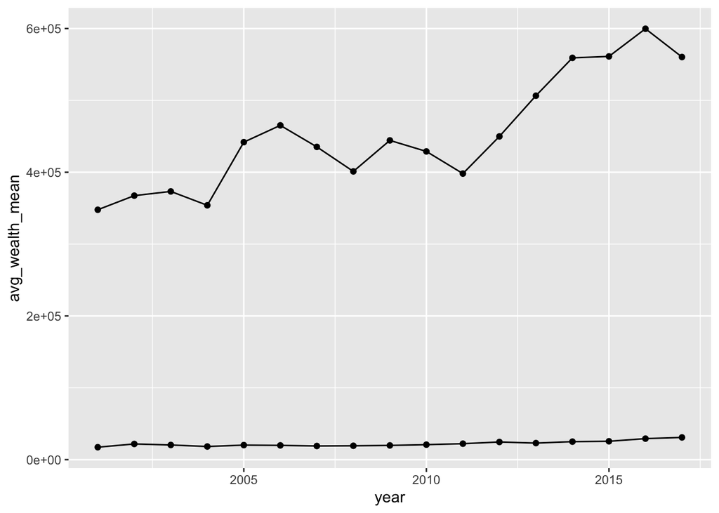

```r
avg_wealth %>%
  ggplot(mapping = aes(x = year,
                       y = avg_wealth_mean)) +
  geom_point() + geom_line() +
  geom_point(aes(y = avg_wealth_median)) +
    geom_line(aes(y = avg_wealth_median))
```

2. Looks like not every Baseler got a lot richer. Increases in medians are much more moderate and there is quite a gap between means and medians. What does that imply for the development of the Gini?

# 4 - Facets

1. Let’s try to bring the Gini into the picture. Since the Gini is on a completely different scale, the best way to do this is facets. Before we can go there, however, you need to transpose `avg_wealth` to the long format. Let the new variables be called `"variable"` and `"value"`. Save the result as `avg_wealth_long`.

```r
avg_wealth_long <- avg_wealth %>%
  pivot_longer(c(avg_wealth_mean, avg_wealth_median, avg_wealth_gini),
               names_to = "variable",
               values_to = "value")
```

2. Use `avg_wealth_long` and `facet_wrap()` to create a plot that illustrates the development for all three variables with points and lines. To do this, `value` must go on the y-axis and `variable` must be used as the faceting variable.

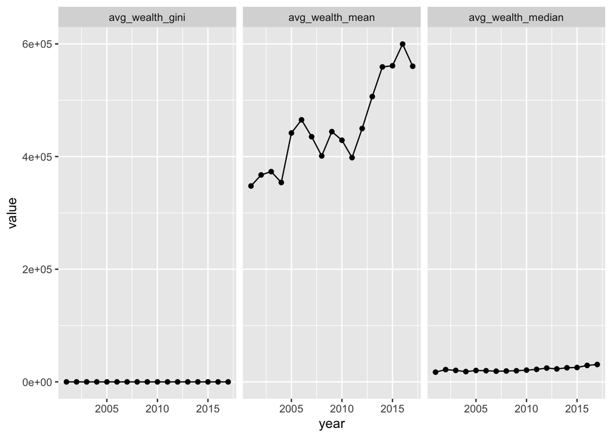

```r
avg_wealth_long %>%
  ggplot(mapping = aes(x = year,
                       y = value)) +
  geom_point() + geom_line() +
  facet_wrap(~ variable)
```

3. Not ideal, right? The problem is that, per default, `ggplot` tries to use the same scales for the different facets. Set `scales = "free"` inside the `facet_wrap` function. Depending on your screen layout you may also want to set `ncol = 1` to have the facets sit on top of each other.

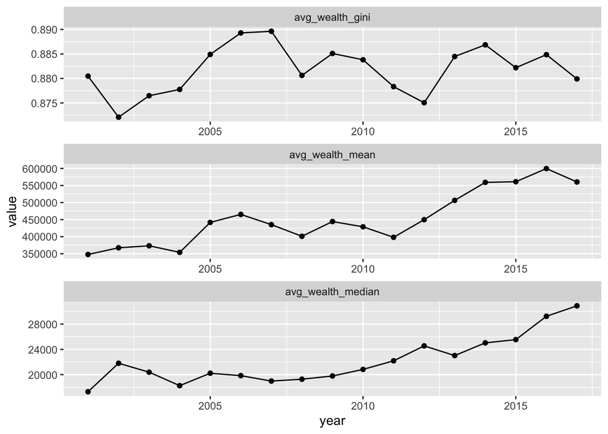

```r
avg_wealth_long %>%
  ggplot(mapping = aes(x = year,
                       y = value)) +
  geom_point() + geom_line() +
  facet_wrap(~ variable, scales = "free", ncol = 1)
```

# 5 - Multiple plots

1. Ok, let’s try to compose the plot of the three wealth metrics in a way that gives the Gini more attention. Specifically, use the `patchwork` package to create a plot with rows where the development of the Gini takes up the entire upper row, while the other two metrics share the lower row. To do this, first create three different plots, one for each of the three panels.

```r
gini_plot <- avg_wealth_long %>%
  filter(variable == "avg_wealth_gini") %>%
  ggplot(mapping = aes(x = year,
                       y = value)) +
  geom_point() + geom_line()

mean_plot <- avg_wealth_long %>%
  filter(variable == "avg_wealth_mean") %>%
  ggplot(mapping = aes(x = year,
                       y = value)) +
  geom_point() + geom_line()

median_plot <- avg_wealth_long %>%
  filter(variable == "avg_wealth_median") %>%
  ggplot(mapping = aes(x = year,
                       y = value)) +
  geom_point() + geom_line()
```

2. Now, use `patchwork` syntax to compose the plot.

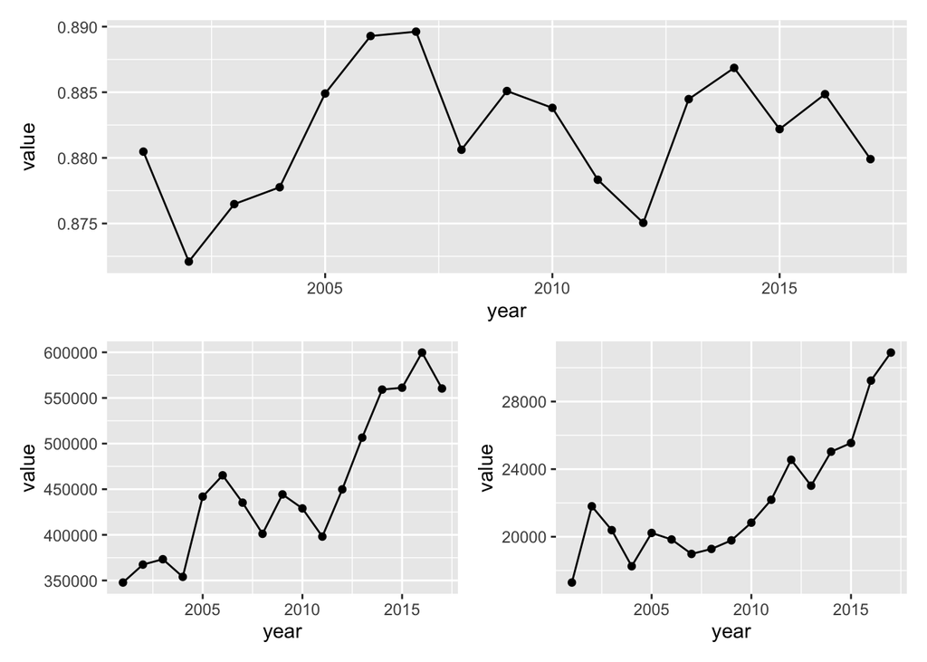

```r
gini_plot / (mean_plot + median_plot)
```

3. Finally, add `plot_annotation(tag_levels = "A")` so that the labels are lettered according to the alphabet.

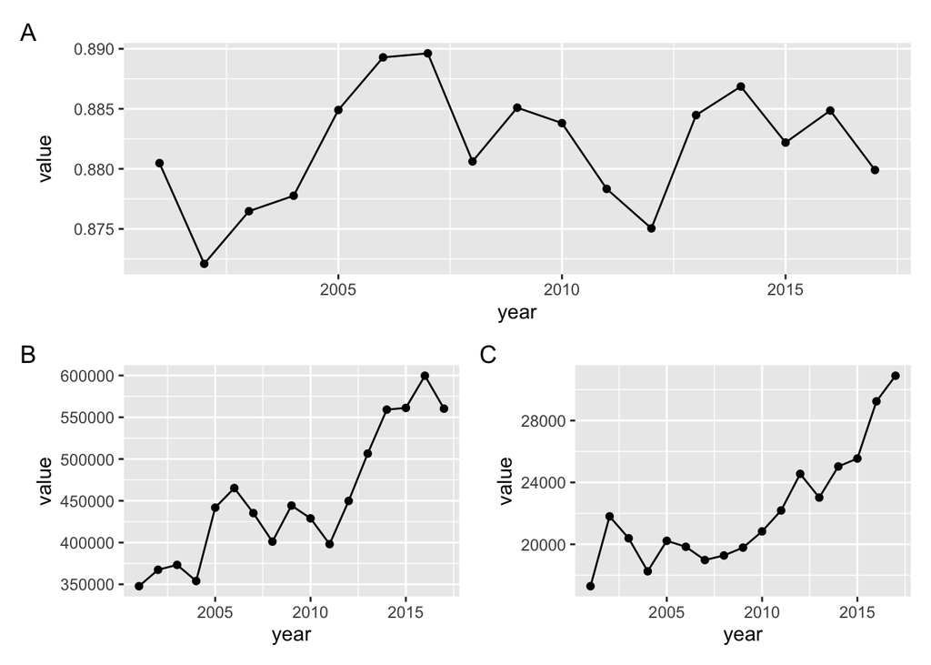

```r
gini_plot / (mean_plot + median_plot) + plot_annotation(tag_levels = "A")
```

# 6 - Project work

1. Try to use what you have learned in this section to visually explore your project data and possibly create a basic version of your data visualization.